# Design Task 4: Educational Attainment

### Visualization 1

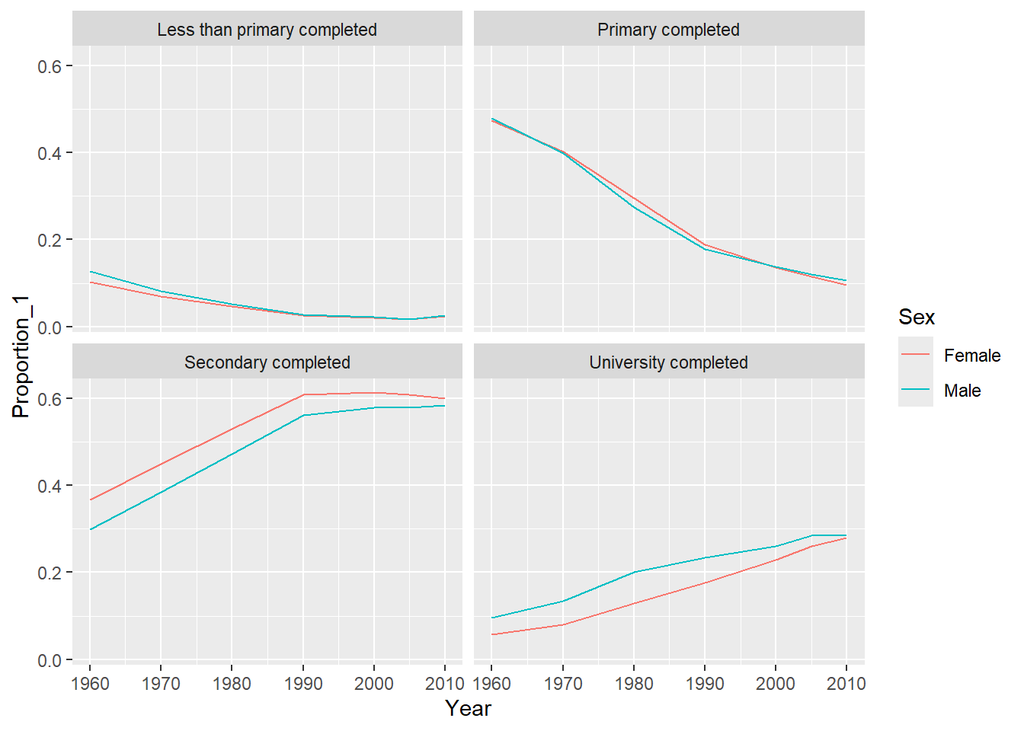

```r
sex_edu_update %>%
  ggplot(aes(x = Year, y = Proportion_1, color = Sex)) +
  geom_line() +
  facet_wrap(~EdAttain)
```

```r
#ggsave()
```

### Visualization 2

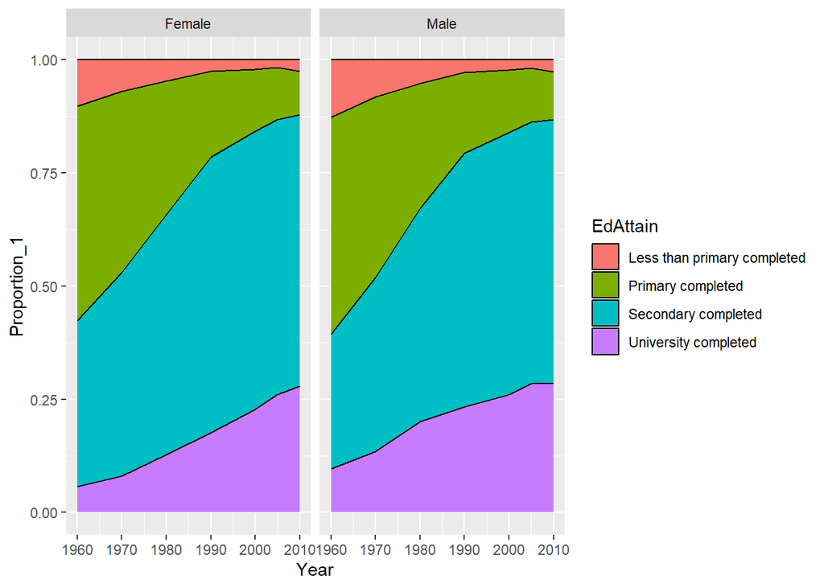

```r
sex_edu_update %>%
  ggplot(aes(x = Year, fill = EdAttain, y = Proportion_1)) +
  geom_density(position = "fill", stat = "identity") +
  facet_wrap(~Sex)
```

```r
#ggsave()
```

### Visualization 3

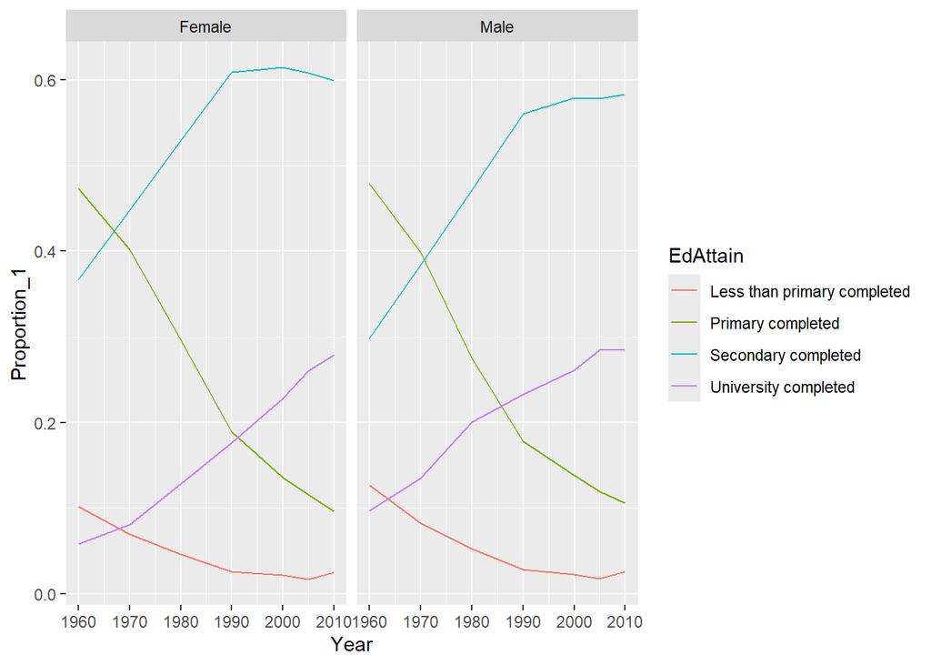

```r
sex_edu_update %>%
  ggplot(aes(x = Year, y = Proportion_1, color = EdAttain)) +
  geom_line() +
  facet_wrap(~Sex)
```

```r
#ggsave()
```

### Visualization 4

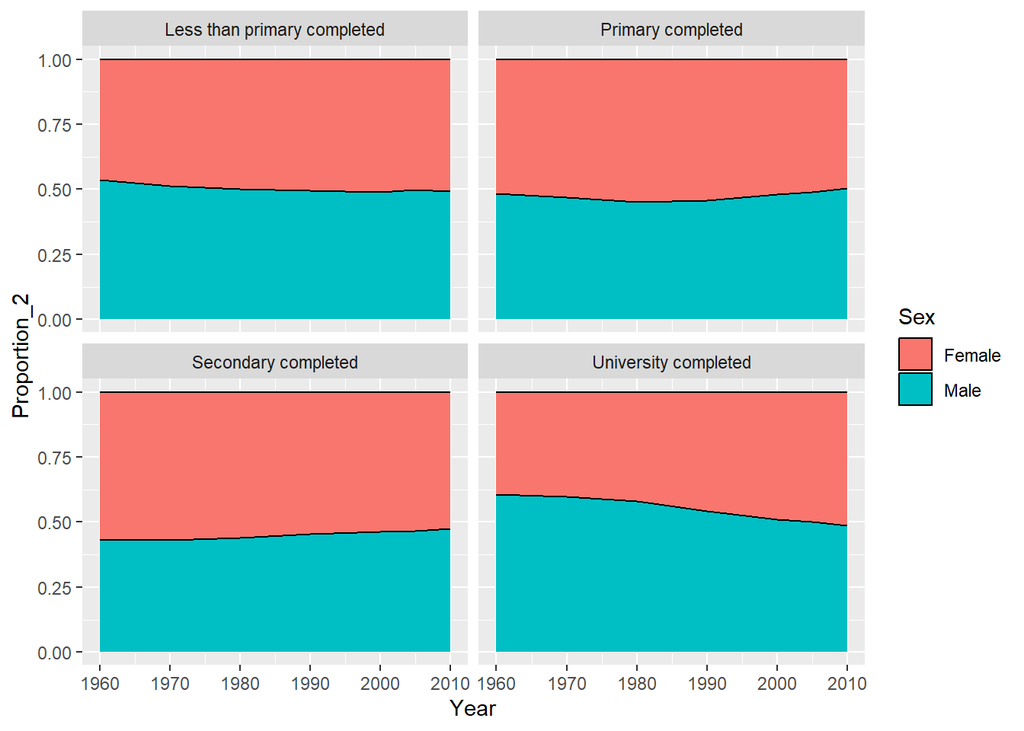

```r
sex_edu_update %>%
  ggplot(aes(x = Year, fill = Sex, y = Proportion_2)) +
  geom_density(position = "fill", stat = "identity") +
  facet_wrap(~EdAttain)
```

```r
#ggsave()
```